# Lettuce Demand Forecasting in Berkeley, CA and New York, NY

### ARIMA Forecast Models

The next step in the project is to develop and ARIMA model that is able to forecast lettuce demand. The ARIMA model will then be compared with the final ETS model above to determine what the truest and most accurate forecast model is.

The outlined tests are completed below in order to determine any trends that might or might not have to be taken into account in the ARIMA model.

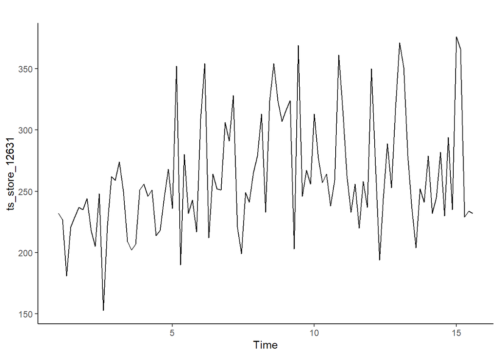

```r
## Arima 12631
autoplot(ts_store_12631) +
  theme(panel.grid.major = element_blank(), panel.grid.minor = element_blank(), panel.background = element_blank(), axis.line = element_line(colour = "black"))## The time series does not look stationary and appears to have multiplicative seasonality as the highs and low get more extreme as the time series goes on. This needs to be addressed by taking the logarithm of the time series to smoothen it out
```

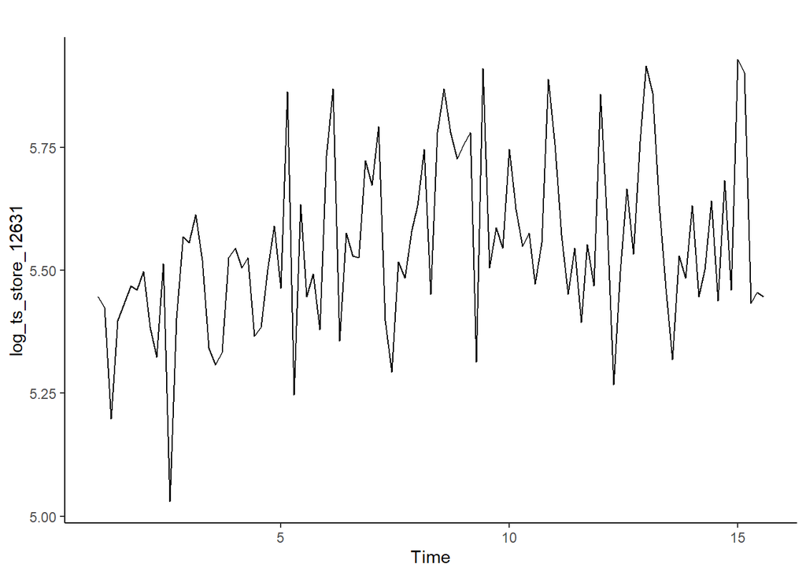

```r
## Logarithm of TS
log_ts_store_12631 <- log(ts_store_12631)
autoplot(log_ts_store_12631) +
  theme(panel.grid.major = element_blank(), panel.grid.minor = element_blank(), panel.background = element_blank(), axis.line = element_line(colour = "black"))
```

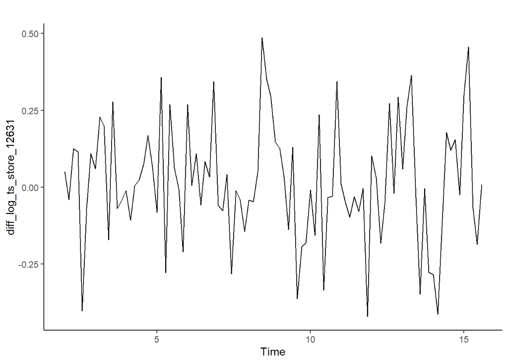

```r
## Differencing is a way of making a time series stationary; this means that you remove any systematic patterns such as trend and seasonality from the data
diff_log_ts_store_12631 <- diff(log_ts_store_12631, lag = frequency(log_ts_store_12631), differences = 1)
autoplot(diff_log_ts_store_12631) +
  theme(panel.grid.major = element_blank(), panel.grid.minor = element_blank(), panel.background = element_blank(), axis.line = element_line(colour = "black"))
```

```r
## Arima Model
## Testing if timeseries of store is stationary
adf.test(ts_store_12631) ## Augmented Dickey–Fuller (ADF) t-statistic test to find if the series has a unit root (a series with a trend line will have a unit root and result in a large p-value)
```

```
##
##  Augmented Dickey-Fuller Test
##
## data:  ts_store_12631
## Dickey-Fuller = -4.6933, Lag order = 4, p-value = 0.01
## alternative hypothesis: stationary
```

```r
kpss.test(ts_store_12631, null = 'Trend') ## Kwiatkowski-Phillips-Schmidt-Shin (KPSS) tests he null hypothesis of trend stationarity (a low p-value will indicate a signal that is not trend stationary, has a unit root)
```

```
##
##  KPSS Test for Trend Stationarity
##
## data:  ts_store_12631
## KPSS Trend = 0.19977, Truncation lag parameter = 4, p-value = 0.01609
```

```r
ndiffs(ts_store_12631)
```

```
## [1] 1
```

```r
nsdiffs(ts_store_12631)
```

```
## [1] 0
```

```r
pp.test(ts_store_12631)
```

```
##
##  Phillips-Perron Unit Root Test
##
## data:  ts_store_12631
## Dickey-Fuller Z(alpha) = -83.052, Truncation lag parameter = 4, p-value
## = 0.01
## alternative hypothesis: stationary
```

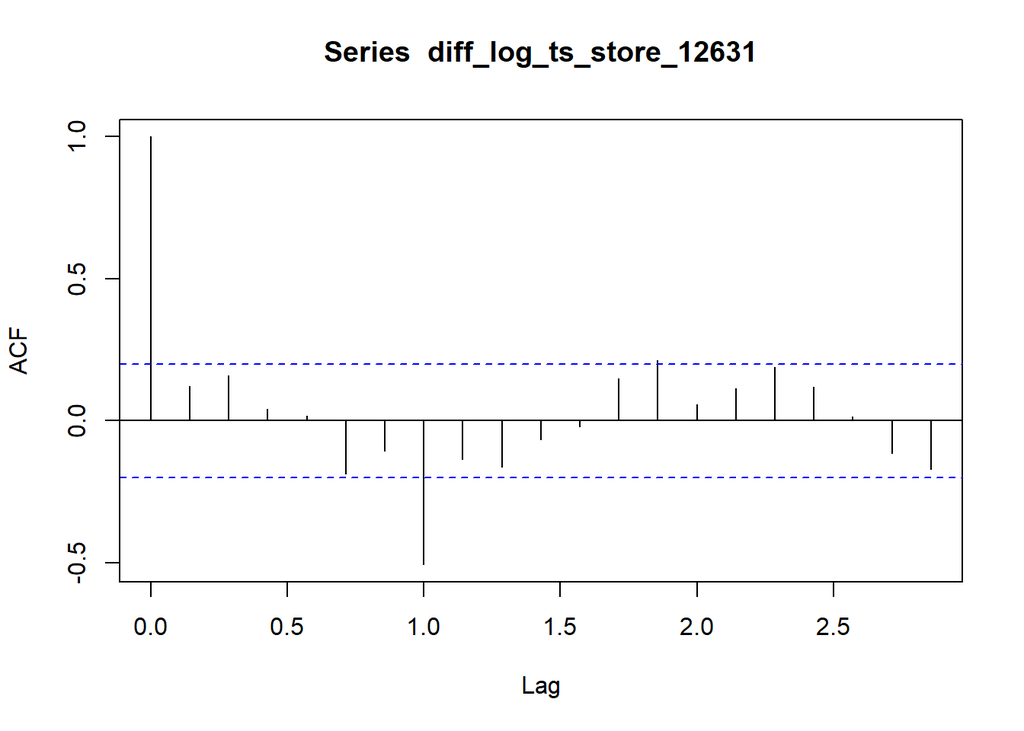

```r
## Next lets look at the ACF plot for the differences
acf(diff_log_ts_store_12631, lag.max = 20)
```

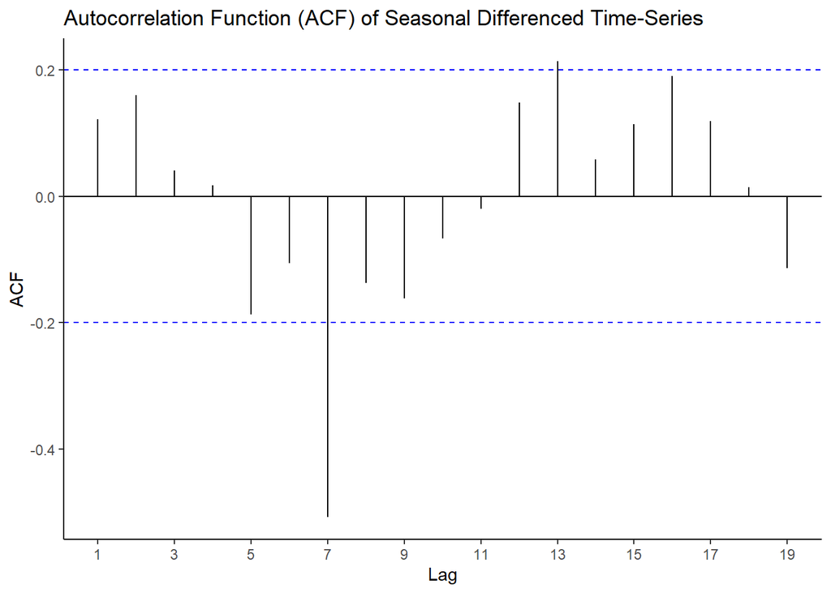

```r
ggAcf(diff_log_ts_store_12631, main = 'Autocorrelation Function (ACF) of Seasonal Differenced Time-Series') +
  theme(panel.grid.major = element_blank(), panel.grid.minor = element_blank(), panel.background = element_blank(), axis.line = element_line(colour = "black")) +
  scale_x_continuous(breaks = seq(1, 100, by = 2))
```

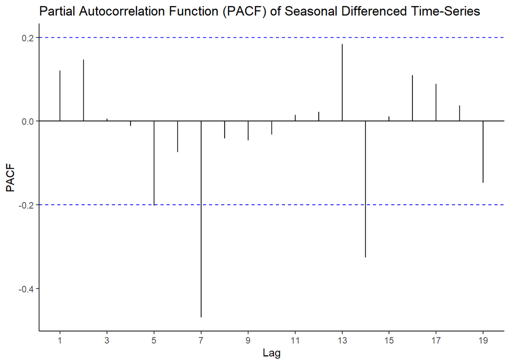

```r
## The partial autocorrelation function gives the partial correlation of a stationary time series with its own lagged values, regressed the values of the time series at all shorter lags. It contrasts with the autocorrelation function, which does not control for other lags.
ggPacf(diff_log_ts_store_12631, main = 'Partial Autocorrelation Function (PACF) of Seasonal Differenced Time-Series') +
  theme(panel.grid.major = element_blank(), panel.grid.minor = element_blank(), panel.background = element_blank(), axis.line = element_line(colour = "black")) +
  scale_x_continuous(breaks = seq(1, 100, by = 2))
```

```r
## Initial auto.arima model that finds 'best model'
auto.arima(ts_store_12631, trace = TRUE, ic = 'bic', approximation = FALSE, lambda = 0) ## Best model is determined to be: Best model: ARIMA(0,1,1)(0,0,2)[7] log likelihood=41.68 AIC=-75.35   AICc=-74.94   BIC=-64.85
```

```
##
##  ARIMA(2,1,2)(1,0,1)[7] with drift         : Inf
##  ARIMA(0,1,0)           with drift         : -12.91423
##  ARIMA(1,1,0)(1,0,0)[7] with drift         : -38.898
##  ARIMA(0,1,1)(0,0,1)[7] with drift         : -60.34469
##  ARIMA(0,1,0)                              : -17.5392
##  ARIMA(0,1,1)           with drift         : -59.92277
##  ARIMA(0,1,1)(1,0,1)[7] with drift         : Inf
##  ARIMA(0,1,1)(0,0,2)[7] with drift         : -61.61351
##  ARIMA(0,1,1)(1,0,2)[7] with drift         : Inf
##  ARIMA(0,1,0)(0,0,2)[7] with drift         : -10.87872
##  ARIMA(1,1,1)(0,0,2)[7] with drift         : -57.49675
##  ARIMA(0,1,2)(0,0,2)[7] with drift         : -57.43068
##  ARIMA(1,1,0)(0,0,2)[7] with drift         : -32.82244
##  ARIMA(1,1,2)(0,0,2)[7] with drift         : Inf
##  ARIMA(0,1,1)(0,0,2)[7]                    : -64.85399
##  ARIMA(0,1,1)(0,0,1)[7]                    : -63.50695
##  ARIMA(0,1,1)(1,0,2)[7]                    : Inf
##  ARIMA(0,1,1)(1,0,1)[7]                    : Inf
##  ARIMA(0,1,0)(0,0,2)[7]                    : -15.50359
##  ARIMA(1,1,1)(0,0,2)[7]                    : -60.57924
##  ARIMA(0,1,2)(0,0,2)[7]                    : -60.5449
##  ARIMA(1,1,0)(0,0,2)[7]                    : -37.44729
##  ARIMA(1,1,2)(0,0,2)[7]                    : -56.00606
##
##  Best model: ARIMA(0,1,1)(0,0,2)[7]
```

```
## Series: ts_store_12631
## ARIMA(0,1,1)(0,0,2)[7]
## Box Cox transformation: lambda= 0
##
## Coefficients:
##           ma1    sma1    sma2
##       -0.9211  0.1488  0.2135
## s.e.   0.0375  0.1146  0.0879
##
## sigma^2 estimated as 0.02603:  log likelihood=41.68
## AIC=-75.35   AICc=-74.94   BIC=-64.85
```